# Urban Green Space and Cardiovascular Health, Mortality Rates, and Life Expectancy across Racial Groups

Lilly Amirjavadi & Joseph Park

2023-03-24

# Introduction

How does the average proximity to green spaces in urban areas impact cardiovascular health, mortality rates, and life expectancy across racial groups? We hypothesize that closer proximity to green spaces will increase cardiovascular health. This research question highlights the importance of public health, particularly across racial groups. Further analysis in this issue area can also impact future urban planning and city development, particularly when it comes to allocating green spaces across counties. This project speaks to the interests of urban developers as well as the public health field. On one hand, urban developers strive to allocate public goods effectively, while health practitioners look to lower disease and mortality rates. These interests intersect when it comes to green spaces, because they can effectively promote voluntary healthy lifestyle choices. *The Access to Parks* dataset will be used to study the allocation of green spaces across counties in California, including the breakdown of average proximity to these spaces among different racial groups. Furthermore, the *Global Health Data Exchange’s U.S. Mortality Rates and Life Expectancy by County, Race, and Ethnicity 2000-2019* and *United States Cardiovascular Disease Mortality Rates by County 1980-2014* datasets will be used to analyze mortality and cardiovascular disease rates across counties of interest. Cross-examination of the three datasets will provide the data necessary to analyze the impact of green space allocation on public health trends.

# Literature Review

Due to the rapid rate of urbanization, there has been a growing concern within the scientific community regarding the availability of green spaces in urban areas. Several studies have linked exposure to green spaces with general health; however, few have specifically looked at urban green spaces. This is particularly important as urbanization continues to grow, with more than half of the world’s population now living in urban areas.

Cicea and Pîrlogea (2011) investigates the vital role of green spaces in fostering sustainable urban development. Their study seeks to address the overarching question of why green areas are crucial in an urban context. According to Cicea and Pîrlogea, there is an accelerated degradation of green spaces resulting from the lack of a clear-cut definition of what green space entails in the legal framework. This gap allows for subjectivity in the interpretation of green space, which can lead to possible misappropriation of vacant land. The situation becomes especially concerning when the ecological and social advantages offered by green spaces are taken into account – the natural treatment of chemicals, bacteria, dust, and noise in the atmosphere, the preservation of native vegetation, promoting social contact between people, encouraging active lifestyles, fulfilling the human need for recreation and leisure – and the potential losses that could occur if they are not preserved in urban environments.

Kondo et al. (2018) conducted an experiment to determine if there is an association between urban green space and human health. The study found a consistent negative association between urban green space exposure and mortality, heart rate, and violence. Furthermore, a positive association was observed between urban green space exposure and attention, mood, and physical activity. These findings suggest that access to urban green spaces could have a positive impact on certain aspects of human health, particularly related to mental health and physical activity.

Richardson et al. (2011) assesses the impact of green spaces on mortality rates on major U.S. cities. In order to do so, the authors observe the impact of the amount of green spaces in a city on mortality rates caused by lung cancer, heart disease, and car accidents. Using previous literature, the authors hypothesize that greater proportions of green spaces in a city will be associated with lower mortality rates. However, after conducting a cross-sectional analysis, the authors do not find such a trend. Thus, their hypothesis could not be supported by their analysis. Adding to existing knowledge on the subject, the authors find that trends that are often found on smaller-scales, such as small cities and neighborhoods, were not evident city-wide. During their analysis, they also accounted for confounding variables such as income and race, which can also play a role in the overall health of a population. Ultimately, the authors suggest re-examining now only the amount of green spaces in a city, but also the way in which they are allocated.

Roe et al. (2015) aimed to investigate the relationship between ethnicity and green spaces. The study explores how general health can differ among ethnic groups, particularly black and minority ethnic (BME) groups, who are believed to suffer from poorer health and a wide range of environment inequalities, such as poor access and provision to urban green spaces. The study employed a survey to gather information regarding the relationship between general health and a range of social and physical environmental predictors. The physical environmental predictors include perceptions of urban green space availability and quality, while the social environmental predictors include place belonging, levels of neighborhood trust, loneliness, and other related factors. The results of the study identified three distinct general health segments, ranging from “very good” health (people of Indian origin), “good” health (white), and “poor” health (people of African-Caribbean and other BME groups). Moreover, satisfaction with local green space as well as perceptions of safety are associated with better health in BME groups, which indicates the importance of green space as a contributor to health outcomes within these communities.

A similar study was conducted by Estabrooks et al. (2003), where they explore the relationship between neighborhood socioeconomic status (SES) and the ability of residents to access available resources. The authors of the study used GIS data and city government data to compile a database of neighborhood physical activity resources and socioeconomic status. Rather than use perceived availability and accessibility data, the authors wanted empirical evidence to base their findings on. Using this data, the authors tested their hypothesis that physical activity resources were varied across neighborhoods with different SES levels. Ultimately, they found that the city they studied consisted of neighborhoods that differed across unemployment, poverty, and income. Within these neighborhoods, those with a higher SES not only had access to more physical activity resources, but those resources were also more likely to be free of charge. Low and medium SES neighborhoods, in contrast, had fewer resources and the resources they did have were more likely to require some form of payment.

The analysis presented by Dajun Dai (2011) makes it apparent that there are disparities across racial and socioeconomic lines when it comes down to access to green spaces in urban areas. Furthermore, previous literature suggests that there is a correlation between access to green space and overall physical health, and the disparities found in this study can be used to explain some of the health differences seen across different groups. By using data from Atlanta, an urban area home to individuals of different ethnic groups and socioeconomic levels, the author showed how green spaces are disproportionately accessible, and that minorities and poorer communities cannot access green spaces at the rate that wealthier, white communities can. The findings of this study can be used by urban planners and city officials to recognize the importance of green spaces in communities and how there are additional factors that can contribute to health inequalities in urban areas. The discussion section of this paper also reflects on the importance of defining accessibility to green spaces not only as how far one has to drive to reach one, but also considering other modes of transportation such as walking, biking, or bussing. Overall, the study posits that a better understanding of green space accessibility can have major policy implications that can advocate for the health and well being of all citizens in metropolitan areas.

# Data

Our project draws data from multiple sources. The first source utilized was the Park, Beach, Open Space, or Coastline Access dataset from the California Health and Human Services Open Data Portal. This dataset can be used to answer the question: How does the average proximity to green spaces in urban areas impact cardiovascular health, mortality rates, and life expectancy across racial groups?, because of its ample information regarding access to green spaces. The dataset includes census data in addition to green space access measures. Most importantly, the dataset has the variables `race_eth_name`, which denotes a person’s race, `numerator`, which is defined as the “Number of residents within ½ mile of a park, beach, open space, or coastline in the geographic unit,” and `denominator`, which is defined as the “Total number of residents in the geographic unit.” These data points will need to be recoded, however, given the fact that our outcome variable of interest is actually cardiovascular health.

With that being said, we also will be drawing data from the United States Cardiovascular Disease Mortality Rates by County 1980-2014 dataset in order to see whether there seems to be a general relationship between proximity to green space and cardiovascular health. This dataset contains measures for our dependent variable, which is cardiovascular health mortality rates. In this dataset, the variable belonging to this measure is `cause_name`, which lists several (cardiovascular-related) causes of mortality including aneurysms and a number of cardiovascular diseases. We will recode this to just set `cause_name` to any instance where it equals “Cardiovascular diseases,” since that is the main outcome we are interested in studying. From here, we can look at the `upper` and `lower` variables, which are the bounds of the estimate of mortality rates caused by cardiovascular diseases. The dataset conveniently supplies the mean between these bounds, which we will use as our outcome variable.

In order to determine whether there are differences in proximity to green space as well as cardiovascular health between racial groups, we will use the Global Health Data Exchange’s U.S. Mortality Rates and Life Expectancy by County, Race, and Ethnicity 2000-2019 dataset. This dataset provides similar features from the previous dataset but separates the features based on racial group.

The final step in regards to our data collection is to merge the three datasets to fit our research needs. The datasets will be merged based on the California county name of each data set, being sure to include the same year, which is the year 2010. From here, we will subset the data to only include variables of interest. These variables will be race, county name, year, cause of mortality, mean estimate mortality rate, life expectacny, and average proximity to green spaces. Using these variables, we will explore the relationship between green space access within California counties and how they can have an effect on overall cardiovascular health. Studying the different outcomes between racial groups will add another dimension to our study, for we can explore disproportionate green space access and its effect on health across racial lines. We have not identified any missing data points, which will not inhibit our analysis.

### Measuring Proximity to Green Space

The independent variable in this study is the proximity to green spaces, which is operationalized as the percentage of residents within a ½ mile radius from a park, beach, open space, or coastline. This measure is based on the `estimate` variable found in the Access to Parks dataset, which provides county-level data and longitudinal data spanning from 2000-2014.

### Measuring Cardiovascular Health

To establish one of our key dependent variables, cardiovascular health, our datasets provide several options. Our variable `cause_name` is a categorical variable with fourteen unique values, ranging from simple, generalized parameters that encapsulate broad categories of disease (“Cardiovascular disease”, “Other cardiovascular and circulatory diseases”) to more specific disease entities such as “Ischemic stroke” and “Endocarditis.” While this feature may have been useful in doing a more thorough recoding of the variables in a way that reflects the severity or progression of different cardiovascular diseases based on existing research and clinical knowledge, it will not necessarily contribute to the aim of the study; therefore, we are choosing to disregard this parameter. Instead, to assess cardiovascular health, we have opted to examine the`mx` variable, which represents the average mortality rate among individuals diagnosed with cardiovascular disease.

# Method

One potential limitation of our analysis concerns the absence of a time variable. Specifically, the Park, Beach, Open Space, or Coastline Access dataset that we utilize only contains information from 2010. This presents a challenge to our ability to perform a time series analysis, which would enable us to investigate whether changes in proximity to green space over time has a significant impact on mortality rates or life expectancy. As a result, we must acknowledge that the analyses undertaken in this study are primarily correlational, and any causal assertions must be grounded in existing literature. To address this issue, the objective of our investigation is to examine whether the data available to us aligns with prevailing theories in the literature. To begin, we will undertake preliminary analyses by visualizing the disparities in proximity to green space and mortality rates across counties. This will provide us with additional insights into the variations that exist between different counties. Afterwards, we will explore whether disparities in proximity to green spaces and mortality rates exist across different races. This will allow us to determine if such disparities are present across racial groups. Finally, we will employ an Ordinary Least Squares Regression model to explore the relationship between proximity to green space and mortality rates.

# Results

Preliminary analysis of the dataset observed in Table 1 suggests that there is no statistically significant association between the proximity of a county to green spaces and its corresponding mortality rate. Although this outcome may be unexpected, it is consistent with the existing literature, which suggests that observable differences in proximity to green spaces only become evident at the neighborhood or small city level, rather than at the city-wide level (Richardson et al., 2011). Given that our dataset comprises information at the county-wide level, we can assume that the same holds true for our investigation.

**Table 1: Regression Results**

| term | estimate | std.error | statistic | p.value |
| --- | --- | --- | --- | --- |
| (Intercept) | 0.0145674 | 0.0002969 | 49.0610867 | 0.0000000 |
| estimate | -0.0000209 | 0.0000270 | -0.7741428 | 0.4394684 |

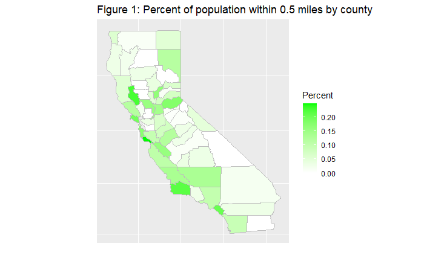

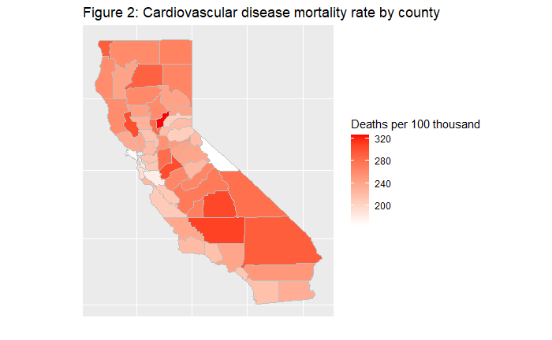

A comparable analysis was performed to explore whether there are any variations in the relationship between proximity to green space and mortality rates across different racial groups. The distribution of the mortality rate across various racial groups (Figure 4) exhibits noteworthy disparities; however, as illustrated in Figure 5, there appears to be little to no difference in proximity to green spaces between different racial groups. Consequently, we cannot establish a correlation between these two variables solely based on visual analysis.

**Table 2: Summary Statistics**

| race_name | prox_mean | mortality_mean |
| --- | --- | --- |
| AIAN | 7.406146 | 0.0175581 |
| AfricanAm | 8.001554 | 0.0163690 |
| Asian | 7.330164 | 0.0101754 |
| Latino | 7.735838 | 0.0113344 |
| Total | 7.569031 | 0.0149854 |
| White | 7.465326 | 0.0158237 |

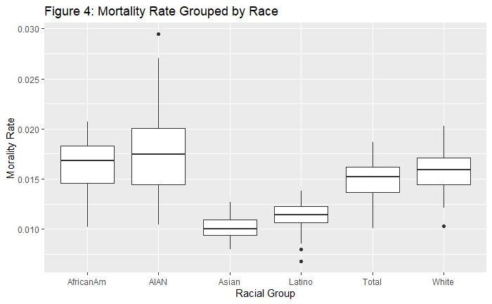

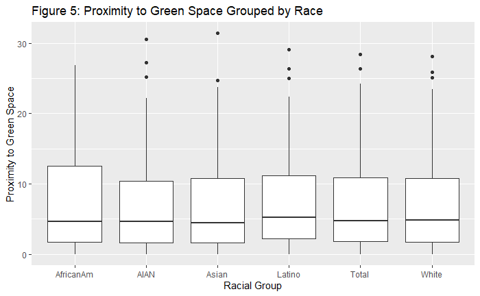

# Discussion

The outputs of the analyses do not support the hypothesis of this project. Initially, it was posited that closer proximity to green spaces will increase cardiovascular health. In other words, we hypothesized that closer proximity to green spaces would be associated with lower mortality rates, particularly those caused by cardiovascular diseases. However, as implied by the results of Tables 1 and 2, the outputs of the tests did not find any relationship between the variables of interest.

It is imperative to recognize the limitations of the study in order to better understand the observed results. The most significant limitation we recognize is the structure of the data. Data were only recorded at the county level, but it may have been more effective to look at nation-wide data. Given the fact that the data were drawn from California urban areas only, there also may have been many similarities between urban areas throughout this region. This could be due to urban planning regulations and trends that exist at the state level. Therefore, it would perhaps be more effective to use data from other urban areas across the entire country in addition to California. That way we could observe a large sample size as well, increasing external validity and perhaps yielding more significant results. Another limitation to the analysis may lie in the definition of health outcomes. In this particular project, we chose to observe the mortality rates as a result of cardiovascular disease. There may be some other health outcome that is perhaps more dependent on green space access that we did not account for, and it would be useful to perhaps look at other health proxies such as obesity rates.

Although the regression analysis did not indicate any causal mechanism between proximity to urban green spaces and cardiovascular health, we argue that this is still an important topic for researchers to investigate. Urban areas, while providing opportunities for economic development and financial growth, must still be able to meet the health needs of its citizens, and that can be achieved through effective allocation of green spaces. As previously mentioned, improvements to this research project may be able to yield more significant results and can thus aid decision making processes regarding urban planning and development.

# References

CICEA, C., & PÎRLOGEA, C. (2011). GREEN SPACES AND PUBLIC HEALTH IN URBAN AREAS. Theoretical and Empirical Researches in Urban Management, 6(1), 83–92. http://www.jstor.org/stable/24873277.

Dajun Dai, D. Dai. (0000). Racial/ethnic and socioeconomic disparities in urban green space accessibility: Where to intervene?. Landscape and urban planning, 102, 234-244. doi: 10.1016/j.landurbplan.2011.05.002.

Estabrooks, P.A., Lee, R.E. & Gyurcsik, N.C. Resources for physical activity participation: Does availability and accessibility differ by neighborhood socioeconomic status?. ann. behav. med. 25, 100–104 (2003). https://doi.org/10.1207/S15324796ABM2502_05.

Kondo, M., Fluehr, J., McKeon, T., & Branas, C. (2018). Urban Green Space and Its Impact on Human Health. International Journal of Environmental Research and Public Health, 15(3), 445. MDPI AG. Retrieved from http://dx.doi.org/10.3390/ijerph15030445.

Richardson, E.A., Mitchell, R., Hartig, T., de Vries, S., Astell-Burt, T., & Frumkin, H. (2011). Green cities and health: a question of scale? Journal of Epidemiology & Community Health, 66, 160 - 165.

Roe, J., Aspinall, P., & Ward Thompson, C. (2016). Understanding Relationships between Health, Ethnicity, Place and the Role of Urban Green Space in Deprived Urban Communities. International Journal of Environmental Research and Public Health, 13(7), 681. MDPI AG. Retrieved from http://dx.doi.org/10.3390/ijerph13070681.